# Library Carpentry Survey 2021

Birgit Schmidt

16 November 2022

# Survey results

The Library Carpentry Advisory Group (LCAG, https://librarycarpentry.org/advisory/) conducted a survey with the aim to gain a better understanding of librarians and other information professionals in terms of their training needs, impacts resulting from training and further engagement with The Carpentries community. The survey has been developed by Birgit Schmidt and Konrad Förstner.

The survey was disseminated through various channels, including The Carpentries mailing lists and social media channels, regional mailing lists (e.g. Australia, Asia, Africa), and direct contacts to former workshop participants and instructors (via host institutions).

The survey consisted of 28 questions overall, and was open for responses between 2021-06-14 and 2021-08-25. Overall 113 responses were collected; all respondents shared some information about their experiences with The Carpentries. About two thirds contributed as an individual (79 responses), 25 as a representative of a member institution and further 9 respondents did not specify a role.

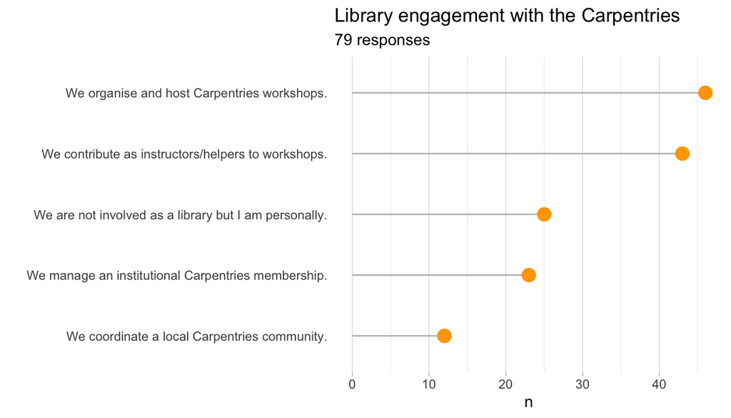

```
## [1] "Just receive e-mails"
## [2] "Want to be more involved (mostly host \"unofficial\" workshops)"
## [3] "We've hosted one carpentries workshop"
## [4] "I only participated as an individual"
## [5] "We organise and host \"based on carpentries\" workshops/hacky hours"
```

Overall, 79 respondents reported that their library already engages with The Carpentries, and several do so in multiple ways. In addition, 19 respondent libraries are not involved yet but they would like to learn more.

Regarding their job roles, respondents were asked to choose up to three work areas.

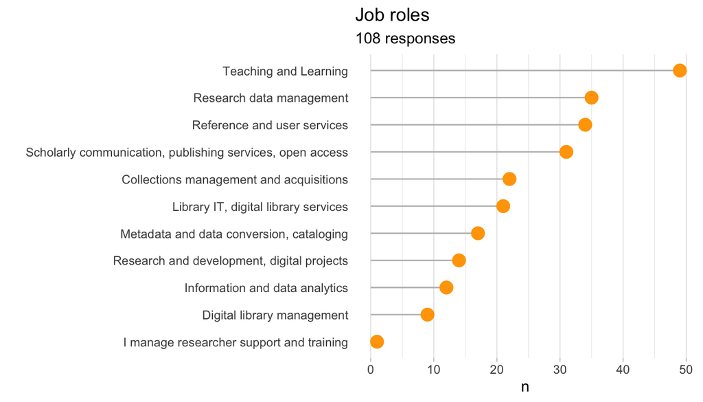

108 respondents shared information on their job roles. `

| workshop_attendance | n |
| --- | --- |
| Library Carpentry | 73 |
| Software Carpentry | 42 |
| Data Carpentry | 38 |
| No | 18 |
| No, but I plan to do so | 7 |
| Taught but not actually attended as a learner! | 1 |

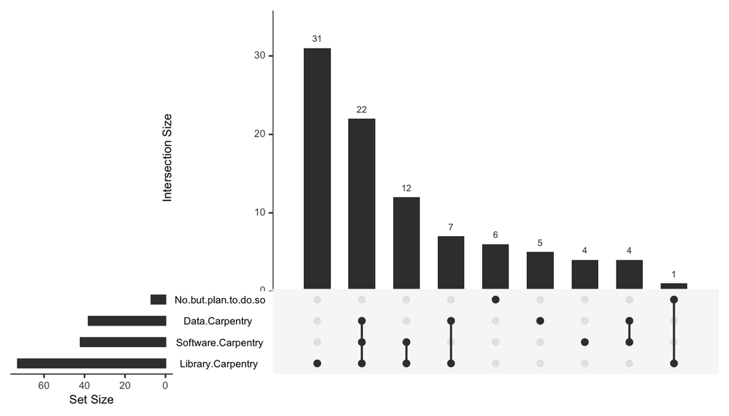

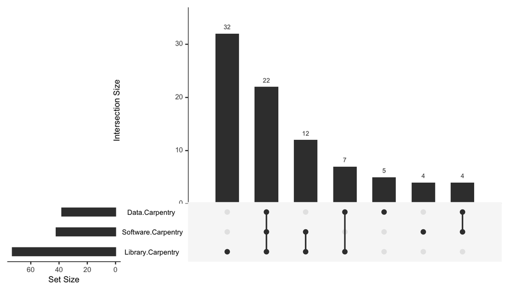

| last_workshop_attended | n |
| --- | --- |
| 0-6 months ago | 41 |
| More than 1 year ago | 32 |
| 7-12 months ago | 11 |

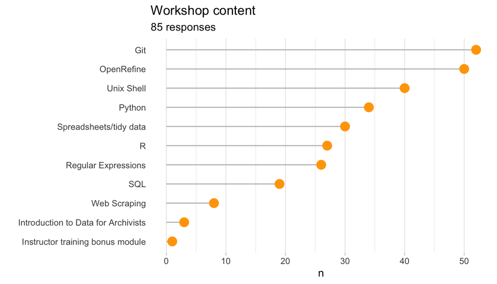

| job_roles | n | perc |
| --- | --- | --- |
| Teaching and Learning | 49 | 45.4 |
| Research data management | 35 | 32.4 |
| Reference and user services | 34 | 31.5 |
| Scholarly communication, publishing services, open access | 31 | 28.7 |
| Collections management and acquisitions | 22 | 20.4 |
| Library IT, digital library services | 21 | 19.4 |
| Metadata and data conversion, cataloging | 17 | 15.7 |
| Research and development, digital projects | 14 | 13.0 |
| Information and data analytics | 12 | 11.1 |
| Digital library management | 9 | 8.3 |

[output cut: 1 more lines]

Of all respondents, 86 had attended at least one Carpentries workhop. Most popular was Library Carpentry (73 respondents), followed by Software Carpentry (42 respondents) and Data Carpentry (38 respondents). Out of these about every second (45 respondents) had attended at least two types of Carpentry workshops.

# Application and engagement

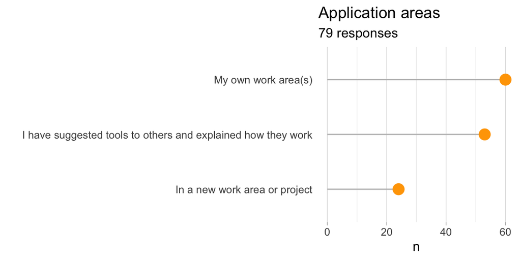

| application_frequency | n |
| --- | --- |
| Monthly | 26 |
| Weekly | 22 |
| Less than once a year | 21 |
| Several times per year | 17 |
| Daily | 6 |

### Adopted routines

Respondents were asked to assess to what degree they have adopted certain behaviours or routines as a result of having completed a Carpentries workshop. The scale of responses was a 7-point Likert scale between never (0), sometimes (3, mid-point) and regularly (6), not all levels were spelled out in the survey questionnaire. The additional levels can be read as very rarely (1), rarely (2), often (4), very often (5).

```
##                                                 Item        0         1
## 1             Reorganising and cleaning spreadsheets 21.64948  6.185567
## 2                              Using version control 28.86598  9.278351
## 3                Transforming workflows into scripts 50.51546 12.371134
## 4                     Scraping or mining web content 56.25000 14.583333
## 5 Improving data management and project organisation 24.74227  7.216495
## 6                        Using programming languages 35.41667 10.416667
## 7                                       Reusing code 34.37500 11.458333
## 8                       Creating processable reports 45.83333 17.708333
##           2        3         4         5         6
## 1  3.092784 22.68041 10.309278 13.402062 22.680412
## 2  6.185567 22.68041  9.278351  8.247423 15.463918
## 3 10.309278 12.37113  8.247423  3.092784  3.092784
## 4  6.250000 14.58333  5.208333  3.125000  0.000000
## 5  7.216495 12.37113 10.309278 11.340206 26.804124
## 6 11.458333 17.70833  7.291667  9.375000  8.333333
## 7  9.375000 16.66667 14.583333  8.333333  5.208333
## 8  7.291667 15.62500  8.333333  3.125000  2.083333
```

|  | Item | low | neutral | high | mean | sd |
| --- | --- | --- | --- | --- | --- | --- |
| 5 | Improving data management and project organisation | 39.17526 | 12.37113 | 48.453608 | 4.175258 | 2.362953 |
| 1 | Reorganising and cleaning spreadsheets | 30.92784 | 22.68041 | 46.391753 | 4.247423 | 2.212799 |
| 2 | Using version control | 44.32990 | 22.68041 | 32.989691 | 3.608247 | 2.177330 |
| 7 | Reusing code | 55.20833 | 16.66667 | 28.125000 | 3.114583 | 1.962114 |
| 6 | Using programming languages | 57.29167 | 17.70833 | 25.000000 | 3.125000 | 2.048106 |
| 3 | Transforming workflows into scripts | 73.19588 | 12.37113 | 14.432990 | 2.371134 | 1.733972 |
| 8 | Creating processable reports | 70.83333 | 15.62500 | 13.541667 | 2.406250 | 1.670664 |
| 4 | Scraping or mining web content | 77.08333 | 14.58333 | 8.333333 | 2.072917 | 1.481427 |

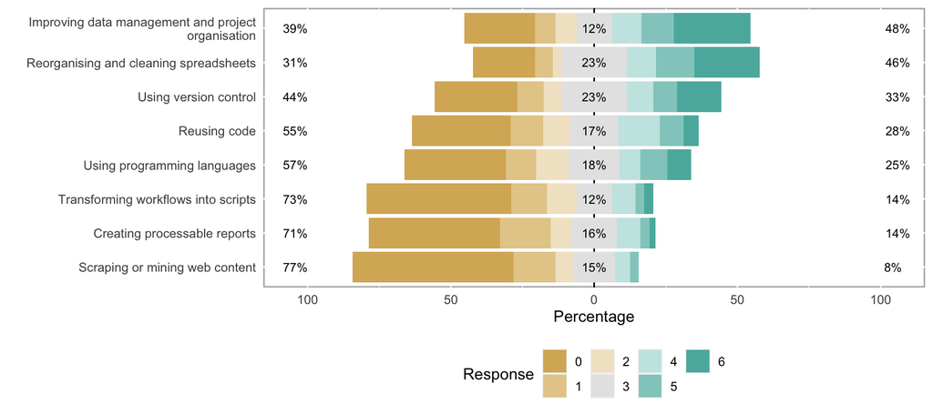

| what_other_behaviours_routines_have_you_adopted_as_a_result_of_completing_a_carpentries_workshop |
| --- |
| Techniques from instructor training, such as making sure everyone in the room understands before we move on, avoiding dismissive language, creating a positive, safe space for people to feel comfortabl… |
| Information governance and extending the domain specificity (away from 'library') towards collections management (records, museums and archives). |
| Using OpenRefine to tidy data |
| Develop new training and improve existing training |
| Gaining a lot of new insights |
| Organise my R workspace in a logical way |
| Adhering to FAIR principles |
| I would really like to learn more about this/get involved in this. |
| Cleaning messy data with open refine |
| Information Literacy |

[output cut: 28 more lines]

### Benefits, follow-up learning and further engagement

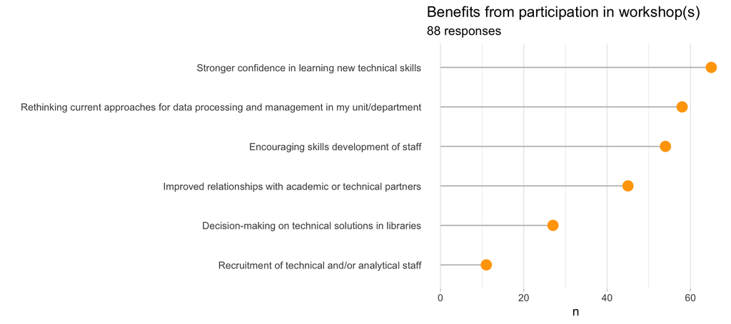

| other_61 |
| --- |
| automated repetitive tasks |

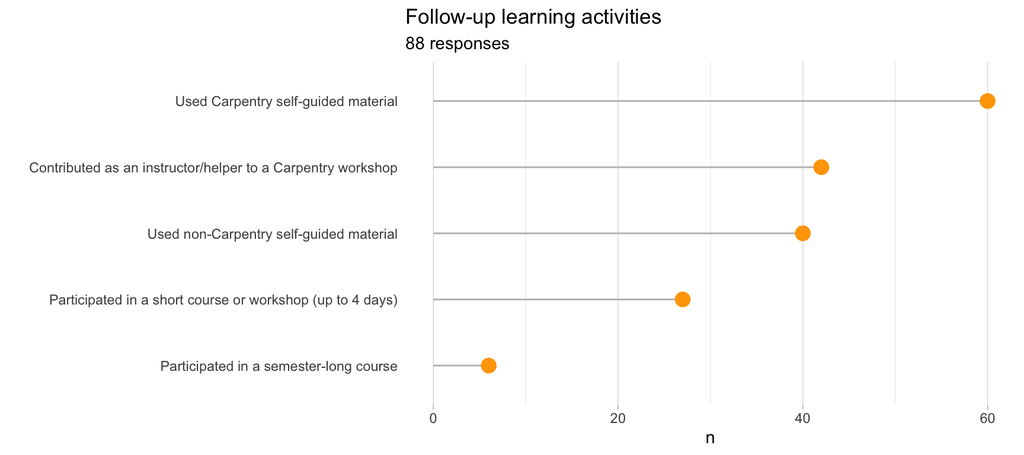

| other_67 |
| --- |
| Contributed to design and delivery of "based on carpentries" workshops |
| started a community of practice at work |

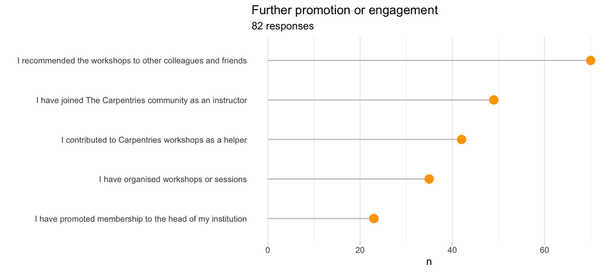

| other_73 |
| --- |
| Haven't done any workshops yet. |
| Helped researchers at my institution via Slack |
| Past maintainer and advisory group member |

# Suggestions and final comments

Respondents shared their ideas on what other topics the Library Carpentry curriculum could include and how Library Carpentry could support them in their work. At the end of the survey, a few respondents shared a couple of final comments.

| what_other_topics_should_the_library_carpentry_curriculum_include |
| --- |
| Examples of what Library Carpentry skills are, and practical examples of how you might use these skills in your work routines. |
| Archivists' Toolkit / Society American Archivists |
| PowerBI\nSPARQL |
| MarcEdit PLEASE omg it has such a steep and impenetrable learning curve. Turning workflows into scripts I saw mentioned earlier in this survey but promoting that to (meta)data librarians would be a bi… |
| Bibliometrics and other research metrics |
| basic data literacy: data as an asset, value of data, etc. |
| How to successfully change over from one area of Librarianship to another. |
| Beginners guide |
| Digital Information |
| Basic computer skills training lesson plans and delivery modes |

[output cut: 35 more lines]

| do_you_have_any_other_suggestions_on_how_library_carpentry_could_support_you_in_your_work |
| --- |
| Adopt consistent global standards (ISO) and collect and publish data on course adoption and use (in the US and elsewhere) |
| Promotional material to show to management and colleagues how the skills learned by following the Library Carpentry curriculum have improved internal processes elsewhere (good examples and user storie… |
| Can I come to America to learn how to implement it in South Africa, Cape Town specifically? |
| It would benefit librarians to sharpen their skills and learn new skills |
| It would be great if all colleauges can attend Library Capentry |
| learn more on metadata |
| Fund is the bottleneck when compared from users need point of view |
| a bit more introduction to 'data set (csv files) discovery' - meaning, how to separate by either comma, semicolon, tab - if a comma is within a dedicated Column. It messes up the whole spreadsheet if … |
| Continued opportunities for us instructors to give back to the Library Carpentry community. Continued collaboration with other Carpentries groups helps me in my outreach to colleagues in other parts o… |
| bite sized online modules that build into a skillset |

[output cut: 10 more lines]

| is_there_anything_else_you_would_like_to_share |
| --- |
| Keep up the good work! |
| Who are you going to send the results of your feedback to? |
| Many questions are irrelevant to a participant that is interested in attending a carpentry workshop but has never attended one before. |
| Keep reaching out, you are changing the way library data should be managed and the change here is visible. |
| Never heard of Library Capentries before this |
| I am a Carpentry FAN GIRL |
| Aligning learning objectives with hot topics in librarianship like data literacy and systematic reviews would be helpful to get more librarians interested in the Carpentries |
| The survey was not what we expected. It was not clear from your email that you wanted responses from practioners. The email indicated you wanted a 'representative' to answer. |
| live coding and faded problems are two of my favorite aspects of carpentries |
| Please offer more opportunities so that others can benefit! |

[output cut: 4 more lines]

# Quotes

Several respondents shared information on how they personally benefitted from their workshop participation or further engagement with The Carpentries. A few were confused by the question.

| we_would_like_to_quote_you_please_share_a_short_statement_on_how_you_personally_benefitted_from_your_workshop_participation_or_further_engagement_with_the_carpentries |
| --- |
| Involvement corresponds with DDAT (digital, data and technology) skills competency \\ Awareness. You know about the skill and have an appreciation of how it is applied in the environment.\nWorking. Yo… |
| This survey is not very good for people who have never heard of The Carpentries, I am intersted in finding out more. |
| The Carpentries provided me a fast-track to teaching digital skills, even without a teaching background. |
| Sincerely wish I could comment, but I haven't had the privilege of doing one yet. |
| I never knew that working with data involves so many stages. Attending carpentries workshop helped me to understand that. |
| I am a certified data carpentry instructor and engaged in Library Advisory Member Group and also Instructor Development Committee Member |
| Gained Awareness and interest, but have not used |
| learned something new |
| The Library Carpentry workshops have given me an insight into what is possible with the data we deal with here at the library. I wouldn't go as far as to say I'm now proficient in the modules taught (… |
| As the coordinator of software/data carpentry workshops at my institutions I have learned how to run an inclusive training and create training focusing on the practical side of learning |

[output cut: 21 more lines]

# Demographics of respondents’ institutions

| how_would_you_classify_your_institution_organisation | n |
| --- | --- |
| University | 78 |
| Public library | 9 |
| Special library | 4 |
| Public research organisation | 3 |
| Private research organisation | 2 |
| Library Association | 1 |

| size_of_the_library_in_terms_of_fte_staff | n |
| --- | --- |
| at least 100 but fewer than 250 | 33 |
| at least 10 but fewer than 50 | 22 |
| at least 50 but fewer than 100 | 22 |
| at least 250 but fewer than 500 | 12 |
| at least 500 | 9 |
| less than 10 | 9 |

| size_of_your_overall_institution_in_terms_of_fte_enrolled_students | n |
| --- | --- |
| at least 20000 | 42 |
| at least 10000 but fewer than 20000 | 28 |
| Not applicable | 16 |
| at least 1000 but fewer than 5000 | 12 |
| at least 5000 but fewer than 10000 | 7 |
| less than 1000 | 3 |

| size_of_the_library_in_terms_of_fte_staff | n |
| --- | --- |
| at least 100 but fewer than 250 | 33 |
| at least 10 but fewer than 50 | 22 |
| at least 50 but fewer than 100 | 22 |
| at least 250 but fewer than 500 | 12 |
| at least 500 | 9 |
| less than 10 | 9 |